# **Détermination du paramètre influant le plus le prix d’un diamant** [Dataset : Diamonds]

Weichen Liao

30/04/2020

#### **INTRODUCTION**

Le but de cette analyse est de déterminer le paramètre qui influence le plus le prix de diamants grâce au dataset `diamonds` inclus dans le package `ggplot2`.

```r
# On importe (et installe si nécessaire) les librairies nécessaires, d'autres seront ajoutées au fur et mesure
#install.packages("ggplot2")
#install.packages("knitr")
library(ggplot2)
library(knitr)

diamonds = ggplot2::diamonds # Chargement dataset diamonds et affectations à une variable

# On affiche les 5 permières lignes de diamonds
kable(diamonds[1:5, ], caption = "Extrait du dataset `diamonds`")
```

Extrait du dataset `diamonds`

| carat | cut | color | clarity | depth | table | price | x | y | z |
| --- | --- | --- | --- | --- | --- | --- | --- | --- | --- |
| 0.23 | Ideal | E | SI2 | 61.5 | 55 | 326 | 3.95 | 3.98 | 2.43 |
| 0.21 | Premium | E | SI1 | 59.8 | 61 | 326 | 3.89 | 3.84 | 2.31 |
| 0.23 | Good | E | VS1 | 56.9 | 65 | 327 | 4.05 | 4.07 | 2.31 |
| 0.29 | Premium | I | VS2 | 62.4 | 58 | 334 | 4.20 | 4.23 | 2.63 |
| 0.31 | Good | J | SI2 | 63.3 | 58 | 335 | 4.34 | 4.35 | 2.75 |

D’après notre dataset, un diamant est caractérisé par 10 paramètres :

- **Prix** (`price`) : le prix du diamant (en $)
- **Carat** (`carat`) : la poids du diamant (en ct)
- **Coupe** (`cut`) : la qualité de la coupe du diamant, allant de correcte à idéal (`Fair`, `Good`, `Very Good`, `Premium`, et `Ideal`)
- **Couleur** (`color`) : la qualité de la couleur du diamant (`D`, `E`, `F`, `G`, `H`, `I`, `J`)
- **Clareté** (`clarity`) : la qualité de la clareté (`I1`, `SI1`, `SI2`, `VS2`, `VS1`, `VVS2`, `VVS1`, `IF`)
- **Longueur** (`x`) : la longueur du diamant (en mm)
- **Largeur** (`y`) : la largeur du diamant (en mm)
- **Hauteur** (`z`) : la hauteur du diamant (en mm)
- **Profondeur** (`depth`) : $\frac{hauteur}{moyenne\ longeur\ et\ largeur}$ (en %)
- **Table** (`table`) : la table du diamant ; $\frac{largeur\ haut\ du\ diamant}{largeur\ diamant}$ (en %)

Notre analyse de ce jeu de données se fera en trois étapes. Nous regarderons d’abord les données (répartitons des prix, etc.), ensuite nous les préparerons pour les analyses plus avancées (nettoyage). Dans une deuxième phase, nous ferons une analyse graphique des données pour déterminer quels sont les paramètres les plus influant sur le prix. Enfin, dans la troisième phase, nous calculerons les corrélations entre les paramètres et la significativité statistique de ces derniers.

#### **1. COMPRHESION DU JEU DE DONNEES**

Dans cette partie nous essayerons de comprendre les données de `diamonds` en regardant les répartions des prix et des carats :

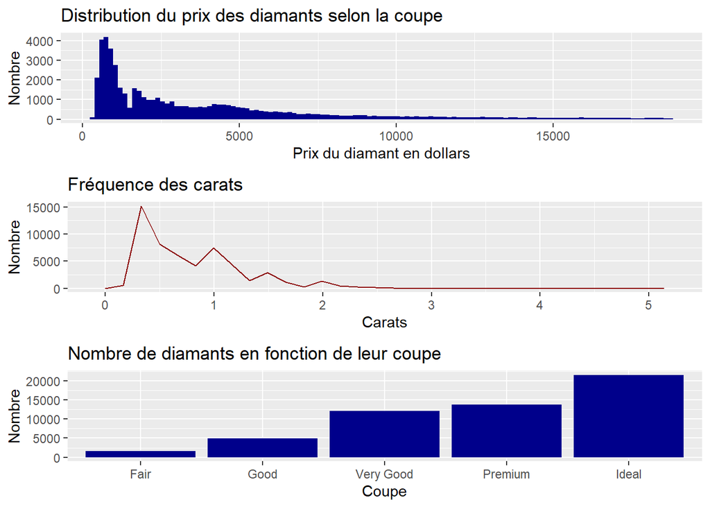

```r
#install.packages("gridExtra")
library(gridExtra)

plot_price = ggplot(diamonds, aes(price)) +
  geom_histogram(binwidth = 150, fill = "dark blue") +
  ggtitle("Distribution du prix des diamants selon la coupe") +
  xlab ("Prix du diamant en dollars") +
  ylab("Nombre")

plot_carat = ggplot(diamonds, aes(x = carat)) +
  geom_freqpoly(color = "dark red") +
  ggtitle("Fréquence des carats") +
  xlab ("Carats") +
  ylab("Nombre")

plot_cut = ggplot(diamonds, aes(cut)) +
  geom_bar(fill = "dark blue") +
  ggtitle("Nombre de diamants en fonction de leur coupe") +
  xlab ("Coupe") +
  ylab("Nombre")

grid.arrange(plot_price, plot_carat, plot_cut, nrow=3) # On affiche tout dans une seule figure avec 0 colonnes (ncol) et 3 lignes (nrow) (utilisation du package GridExtra)
```

Avant de continuer notre analyse, nous allons élimner les valeurs abérantes pour toutes les variables continues.

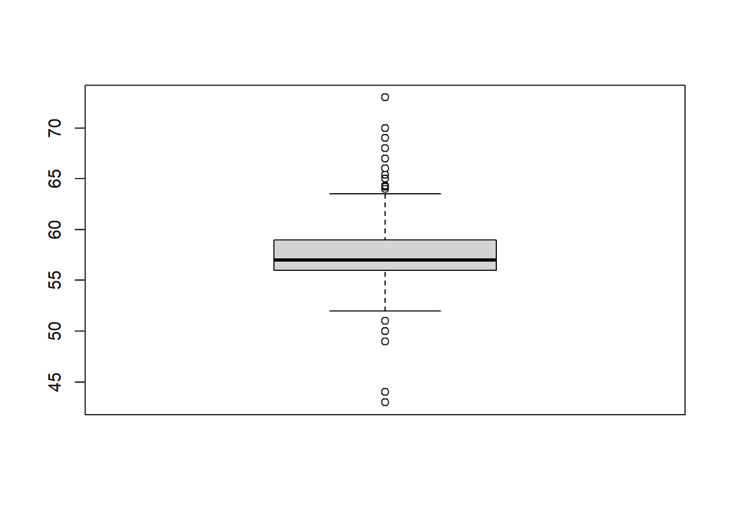

```r
outliers_price = boxplot(diamonds$price, plot=FALSE)$out # Retourne les valeurs abérantes
diamonds = diamonds[-which(diamonds$price %in% outliers_price),] # Enlève les valeurs abérantes dans la colonne

outliers_carat = boxplot(diamonds$carat, plot=FALSE)$out
diamonds = diamonds[-which(diamonds$carat %in% outliers_carat),]

outliers_x = boxplot(diamonds$x, plot=FALSE)$out
diamonds = diamonds[-which(diamonds$x %in% outliers_x),]

outliers_y = boxplot(diamonds$y, plot=FALSE)$out
diamonds = diamonds[-which(diamonds$y %in% outliers_y),]

outliers_z = boxplot(diamonds$z, plot=FALSE)$out
diamonds = diamonds[-which(diamonds$z %in% outliers_z),]

outliers_depth = boxplot(diamonds$depth, plot=FALSE)$out
diamonds = diamonds[-which(diamonds$depth %in% outliers_depth),]

# On affiche à qui ressemble le boxplot avant éliminer les outliers de la colonne Table
outliers_table = boxplot(diamonds$table, plot=TRUE)$out
```

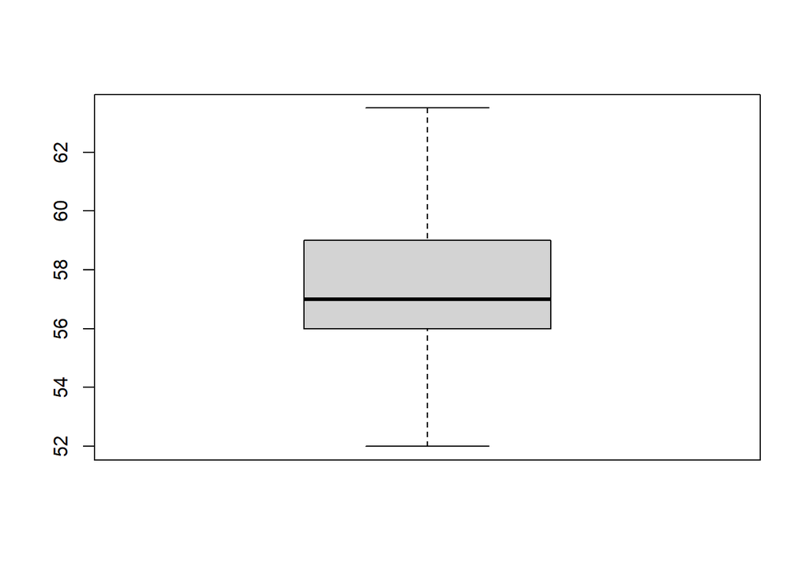

```r
diamonds = diamonds[-which(diamonds$table %in% outliers_table),]

# Et après élimination
outliers_table_apres = boxplot(diamonds$table, plot=TRUE)$out
```

#### **2. ANALYSE GRAPHIQUE**

**Objectif :** Déterminer grâce à différents graphiques quels sont les paramètres les plus important pour déterminer le prix dans ce jeu de données.

**Résultats :**

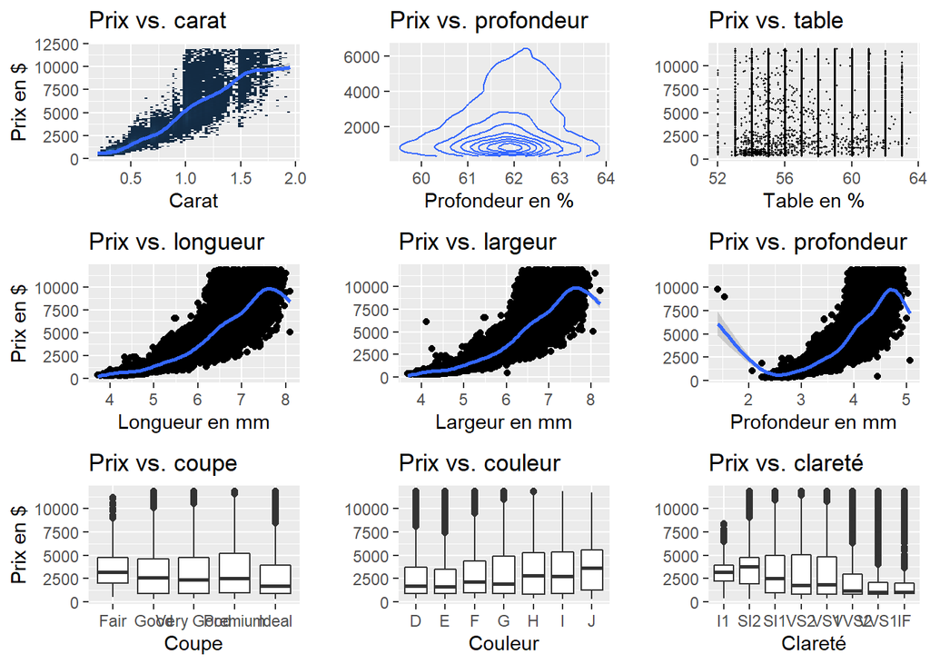

```r
# On trace les 9 graphiques en utilisant ggplot et les geoms
price_carat = ggplot(diamonds, aes(carat, price)) +
  geom_bin2d(binwidth = c(0.025, 125)) +
  geom_smooth() +
  ggtitle("Prix vs. carat") + # Titre du graphique
  ylab("Prix en $") + # Nom de l'axe des ordonnées
  xlab("Carat") + # Nom de l'axe des abscisse
  theme(legend.position = "none") # Position de la légende => ici on ne l'affiche pas

price_depth = ggplot(diamonds, aes(depth, price)) +
  geom_density2d() +
  ggtitle("Prix vs. profondeur") +
  xlab("Profondeur en %") +
  ylab("")

price_table = ggplot(diamonds, aes(table, price)) +
  geom_point(size = 0.25)+
  ggtitle("Prix vs. table") +
  xlab("Table en %") +
  ylab("")

#grid.arrange(price_carat, price_depth, price_table, ncol = 3)

price_x = ggplot(diamonds, aes(x, price)) +
  geom_point() +
  geom_smooth() +
  ggtitle("Prix vs. longueur") +
  ylab("Prix en $") +
  xlab("Longueur en mm")

price_y = ggplot(diamonds, aes(y, price)) +
  geom_point() +
  geom_smooth() +
  ggtitle("Prix vs. largeur") +
  xlab("Largeur en mm") +
  ylab("")

price_z = ggplot(diamonds, aes(z, price)) +
  geom_point() +
  geom_smooth() +
  ggtitle("Prix vs. profondeur") +
  xlab("Profondeur en mm") +
  ylab("")

#grid.arrange(price_carat, price_depth, price_table, price_x, price_y, price_z, ncol = 3)

price_cut = ggplot(diamonds, aes(cut, price)) +
  geom_boxplot() +
  ggtitle("Prix vs. coupe") +
  ylab("Prix en $") +
  xlab("Coupe")

price_color = ggplot(diamonds, aes(color, price)) +
  geom_boxplot() +
  ggtitle("Prix vs. couleur") +
  xlab("Couleur") +
  ylab("")

price_clarity = ggplot(diamonds, aes(clarity, price)) +
  geom_boxplot() +
  ggtitle("Prix vs. clareté") +
  xlab("Clareté") +
  ylab("")

#grid.arrange(price_cut, price_color, price_clarity, ncol = 3)

grid.arrange(price_carat, price_depth, price_table, price_x, price_y, price_z, price_cut, price_color, price_clarity, nrow = 3, ncol = 3)
```

**Discussion :** On observe que dans ce dataset, les graphiques du carat (`carat`) et des dimensions (`x`, `y`, et `z`) ont les plus grandes pentes. Cela nous indique, que ces paramètres sont les ceux qui influencent le plus le prix (`price`).  
De plus, pour une profondeur (`depth`) autour de 62%, on constate la plus grande densité (en nombre) et les prix les plus haut. Cette variable a donc une légère influence sur le prix. Cependant, on observe pour la coupe (`cut`), la clareté (`clarity`), et la couleur (`color`), un effet inverse; les diamants de coupes, claretés, et de couleur de plus grande qualité semblent avoir un prix inférieur aux moins bonnes.  
Enfin, la table (`table`), ne semble pas avoir une influence sur le prix quand bien même on observe une plus grande densité entre 53% et 55%.

**Conclusion :** Les données nous indique qu’il y une première classe de variables à forte influence (carats et dimensions), et une deuxième classe de faible influence (profondeur et couleur).  
Il semble logique que si le carat a une grande influence, alors les dimensions aussi. En effet, le carat est une mesure de poids, et plus un diamant est grand, plus il pèse lourd.  
Concernant le caractère étrange de la coupe, la clareté et de la couleur, il semble que les diamants avec des coupes idéales et une qualité de clareté et de couleur hautes, soient plus petits en taille (du au fait d’enlever de la matière pour atteindre ces qualités et coupes). Comme ils sont plus petits, cela affecte négativement le prix.

#### **3. ANALYSE NUMERIQUE - MATRICE DE CORRELATION**

**Objectif :** Confirmer l’analyse graphique par des calculs numériques :

- **Coefficient de corrélation de Pearson :** à quel point deux variables sont correlés (de 1 à -1, avec 1 une corrélation postive parfaite et -1 une corrélation négative parfaite).
- **P-value :** si cette corrélation est statistiquement significativité (importance) de cette corrélation (pour qu’elle le soit, on choisi de manière arbitraire la valeur 0.01).

**Méthode :** La difficulté ici est de calculer la corrélation entre des variables continues et catégoriques. Il existe plusieurs méthodes, mais elles sont assez complexes et pas adapté pour cet exercice. Toutes les variables discrètes correspondant à des échelles de qualité, on peut faire une équivalence avec un système de notation. Elles deviennents :

- **Coupe :** de 1 (`Fair`) à 5 (`Ideal`),
- **Couleur :** de 1 (`J`) à 7 (`D`),
- **Clareté :** de 1 (`I1`) à 8 (`IF`).

Ensuite, nous calculerons les différents coéfficients pour vérifier notre analyse graphique.

**Résultats :**

```r
# Nous commençons par transformer les variables discrètes en continues : on ajoute une nouvelle colonne avec le score correspondant au niveau de qualité/coupe
# variable Cut
cut_categories = c("Fair", "Good", "Very Good", "Premium", "Ideal")
cut_scales = c(1,2,3,4,5)
diamonds$cut_scale = cut_scales[match(diamonds$cut, cut_categories)]

# variable Color
color_categories = c("D", "E", "F", "G", "H", "I", "J")
color_scales = c(7,6,5,4,3,2,1)
diamonds$color_scale = color_scales[match(diamonds$color, color_categories)]

# variable Clarity
clarity_categories = c("I1","SI2","SI1","VS2","VS1","VVS2","VVS1","IF")
clarity_scales = c(1,2,3,4,5,6,7,8)
diamonds$clarity_scale = clarity_scales[match(diamonds$clarity, clarity_categories)]

# On supprime les anciennes colonnes
diamonds$cut = NULL
diamonds$color = NULL
diamonds$clarity = NULL

# Calcul des coefficients sous forme de matrices : on utilise la fonction rcorr du package Hmisc
#install.packages("Hmisc")
#install.packages("lattice")
#install.packages("survival")
#install.packages("Formula")
library(lattice)
library(survival)
library(Formula)
library(Hmisc)
```

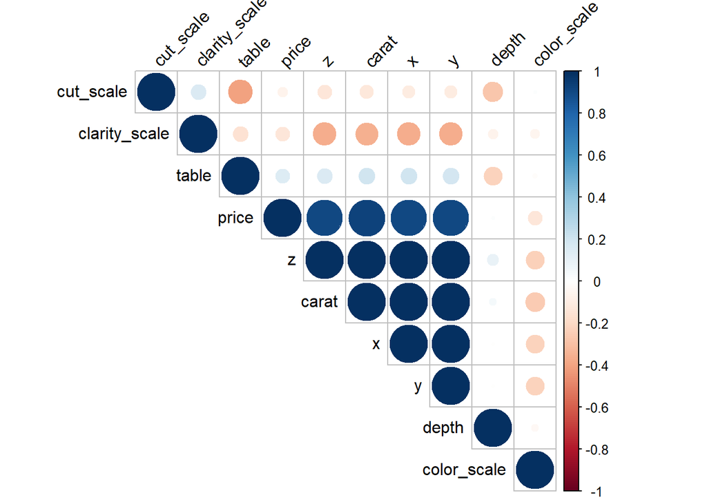

```r
matrix_analysis = rcorr(as.matrix(diamonds)) # Cette fonction nous donne la matrice r de corrélations (coefficient r de Pearson) et la matrice P de p-values
matrix_analysis$r = round(matrix_analysis$r, 2) # On arrondi les nombres à deux chiffre après la virgule

#install.packages("corrplot")
library(corrplot)
corrplot(matrix_analysis$r, type = "upper", order = "hclust",
         tl.col = "black", tl.srt = 45) # Trace une matrice sour format graphique
```

```r
# On utilise/crée une fonction (de http://www.sthda.com/english/wiki/correlation-matrix-formatting-and-visualization) pour transformer notre matrice précédente en tableau
# ++++++++++++++++++++++++++++
# flattenCorrMatrix
# ++++++++++++++++++++++++++++
# cormat : matrix of the correlation coefficients
# pmat : matrix of the correlation p-values
flattenCorrMatrix <- function(cormat, pmat) {
  ut <- upper.tri(cormat)
  data.frame(
    row = rownames(cormat)[row(cormat)[ut]],
    column = rownames(cormat)[col(cormat)[ut]],
    cor  =(cormat)[ut],
    p = pmat[ut]
  )
}

matrix_analysis_table = flattenCorrMatrix(matrix_analysis$r, matrix_analysis$P)

# On affiche seulement les lignes du tableau contenant le prix car on s'intéresse à l'influence sur celle ci
library(dplyr)
filter(matrix_analysis_table, row == "price" | column == "price")
```

```
##     row        column   cor          p
## 1 carat         price  0.92 0.00000000
## 2 depth         price  0.01 0.07889217
## 3 table         price  0.14 0.00000000
## 4 price             x  0.90 0.00000000
## 5 price             y  0.90 0.00000000
## 6 price             z  0.90 0.00000000
## 7 price     cut_scale -0.07 0.00000000
## 8 price   color_scale -0.14 0.00000000
## 9 price clarity_scale -0.14 0.00000000
```

**Discussion :** On observe de fortes corrélations positives (r >= 0.9) et statistiquement significatives (P < 0.01) entre le prix et le carat, ainsi qu’entre le prix et les dimensions.  
On constate aussi des corrélations faiblement négatives (r < -0.05) et et statistiquement significatives (P < 0.01) entre le prix et la coupe, la qualité, et la couleur.  
Il y a aussi une corrélaion faiblement positive (r = 0.14) et statistiquement significatives (P < 0.01) entre le prix et la table.  
Enfin, on n’observe pas de corrélation statistiquement significative (r = 0.01 et P = 0.08 > 0.01) entre le prix et la profondeur.

**Conclusion :** La matrice de corrélations confirme bien les caractères influant du carat et des dimension, ainsi que l’influence faiblement inverse de la coupe, la clareté, et la couleur.  
Cependant, c’est plutôt la table et non la profondeur qui a une influence légèrement positive sur le prix.

#### **CONCLUSION**

Cette analyse nous a montré que dans le dataset `diamonds`, **le paramètre le plus influant est le carat** (r = 0.92). Ce dernier est fortement dépendant aux dimensions, d’où aussi la forte corrélation positive des dimensions sur le prix (r = 0.90).  
Dûes aux pertes de matières pour atteindres des qualités et une coupe supérieures, les prix tendent à baisser. Par contre, pour un même nombre de carats, ces diamants sont plus coûteux (graphiques ci-dessous).

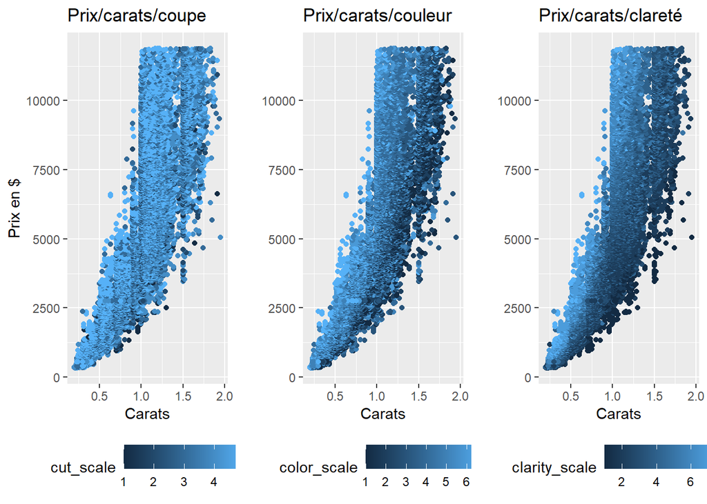

```r
# On affiche les trois graphiques entre le prix et le carat avec en couleur la coupe, la couleur, et la clareté
price_carat_cut = ggplot(diamonds, aes(carat, price)) +
  xlab("Carats") +
  ylab("Prix en $") +
  ggtitle("Prix/carats/coupe") +
  geom_point(mapping=aes(color=cut_scale)) +
  theme(legend.position = "bottom")

price_carat_color = ggplot(diamonds, aes(carat, price)) +
  xlab("Carats") +
  ylab("") +
  ggtitle("Prix/carats/couleur") +
  geom_point(mapping=aes(color=color_scale)) +
  theme(legend.position = "bottom")

price_carat_clarity = ggplot(diamonds, aes(carat, price)) +
  xlab("Carats") +
  ylab("") +
  ggtitle("Prix/carats/clareté") +
  geom_point(mapping=aes(color=clarity_scale)) +
  theme(legend.position = "bottom")

grid.arrange(price_carat_cut, price_carat_color, price_carat_clarity, ncol = 3)
```